# ProjecTILs heatmap of predicted cell subtypes

This short tutorial shows how to use the `celltype.heatmap` function from `ProjecTILs`.

`celltype.heatmap` takes the output object of `ProjecTILs` and displays an averaged gene expression profile for each predicted cell subtype (functional.cluster) split by any metadata columns (e.g. patient, tissue).

# R environment

First, let’s check package dependencies.

```r
Sys.setenv(R_REMOTES_NO_ERRORS_FROM_WARNINGS = "true")
options(timeout = max(900, getOption("timeout")))

if (!requireNamespace("renv")) install.packages("renv")
library(renv)
renv::restore()
```

```
* The library is already synchronized with the lockfile.
```

```r
library(ProjecTILs)
library(Seurat)
library(tidyr)
library(pheatmap)
library(dplyr)
```

# Load the human TIL CD8 reference from FigShare.

```r
ref <- load.reference.map(ref = "https://figshare.com/ndownloader/files/38921366")
```

```
[1] "Trying to download custom reference from https://figshare.com/ndownloader/files/38921366..."
[1] "Loading Custom Reference Atlas..."
[1] "Loaded Custom Reference map Human CD8 TILs"
```

# Parameters overview

Now we can use this reference as our input Seurat object to test the different functions from `celltype.heatmap`. Let’s have a first look at the default plotting behavior. We need to provide at least one metadata to display on the heatmap using the `metadata` argument.

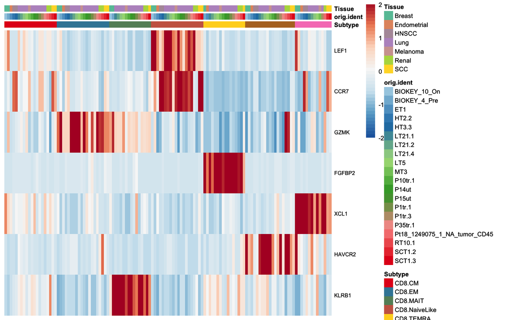

```r
celltype.heatmap(ref, genes = c("LEF1", "CCR7", "GZMK", "FGFBP2", "XCL1", "HAVCR2",
    "KLRB1"), metadata = c("orig.ident", "Tissue"))
```

## Set colors with reference

We can give the reference used to fix the colors and order of the clusters used, with the `ref` parameter.

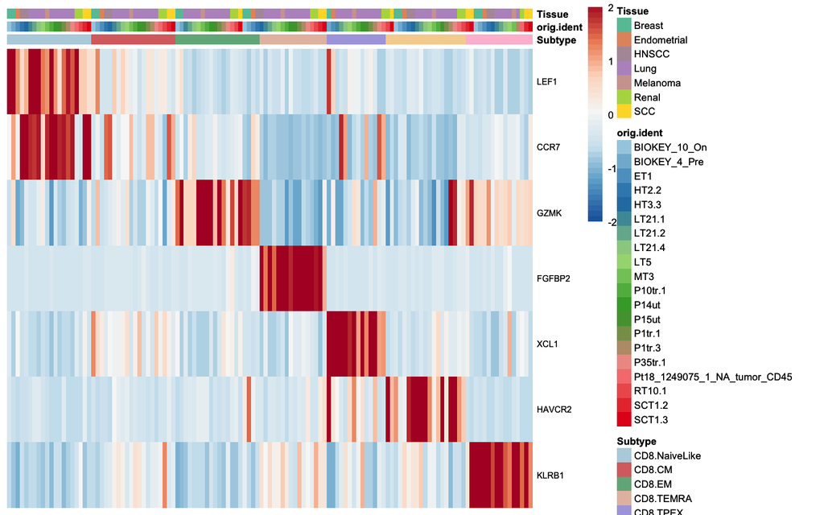

```r
celltype.heatmap(ref, genes = c("LEF1", "CCR7", "GZMK", "FGFBP2", "XCL1", "HAVCR2",
    "KLRB1"), ref = ref, metadata = c("orig.ident", "Tissue"))
```

## Change minimum of cells per sample threshold

We can select the minimum number of cells a sample should have to be considered using the `min.cells` parameter. This value is set at 10 cells by default.

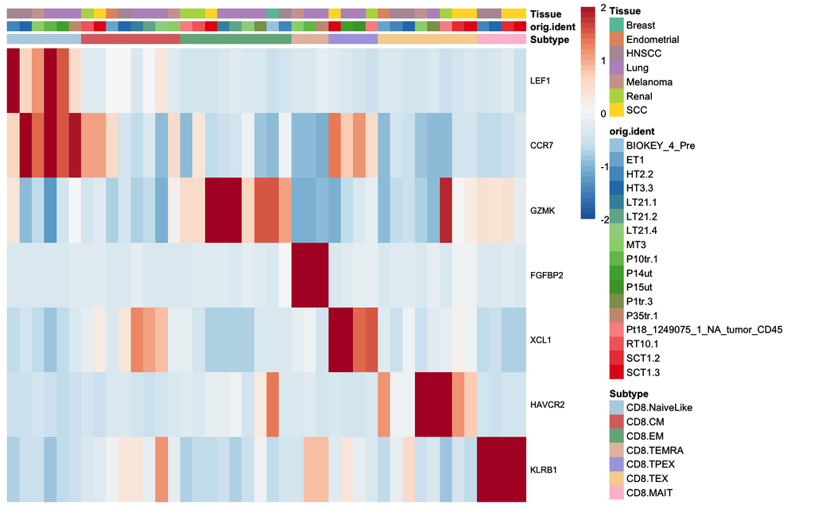

```r
celltype.heatmap(ref, genes = c("LEF1", "CCR7", "GZMK", "FGFBP2", "XCL1", "HAVCR2",
    "KLRB1"), ref = ref, metadata = c("orig.ident", "Tissue"), min.cells = 100)
```

## Change order of heatmap columns

We can also decide to order the heatmap by specific metadata columns with `order.by` parameter. Let’s see how it looks.

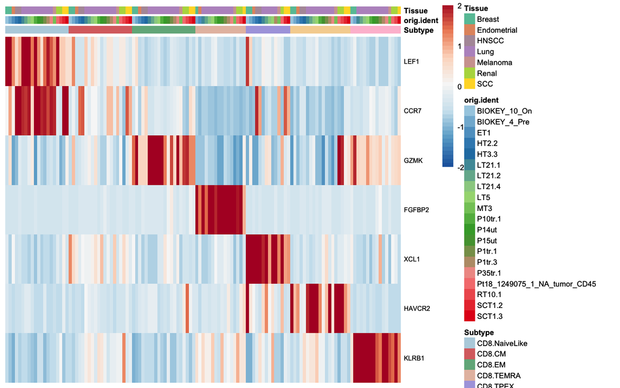

```r
celltype.heatmap(ref, genes = c("LEF1", "CCR7", "GZMK", "FGFBP2", "XCL1", "HAVCR2",
    "KLRB1"), ref = ref, metadata = c("orig.ident", "Tissue"), order.by = "Tissue")
```

## Remove/keep NA metadata

By default, samples with metadata as NA will be removed, but we can remove this parameter with `remove.NA.meta` = FALSE, as shown here with the `cloneType` metadata.

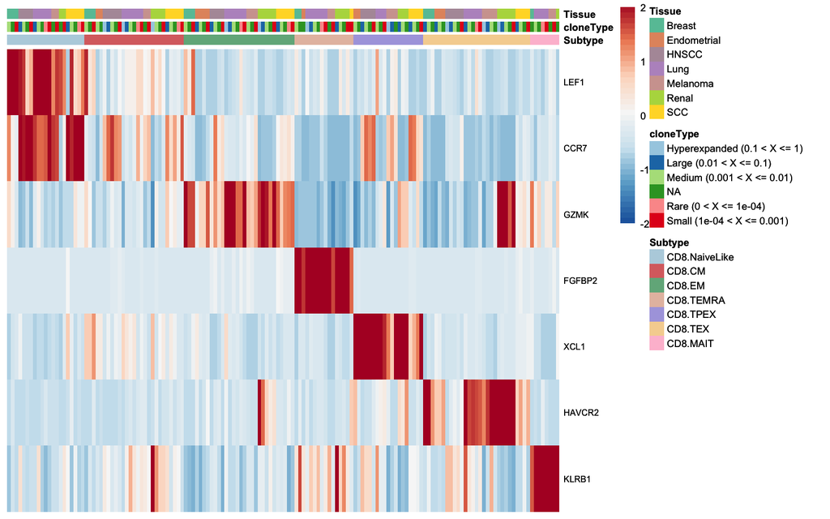

```r
celltype.heatmap(ref, genes = c("LEF1", "CCR7", "GZMK", "FGFBP2", "XCL1", "HAVCR2",
    "KLRB1"), ref = ref, metadata = c("cloneType", "Tissue"), order.by = "Tissue",
    remove.NA.meta = F)
```

## Cluster genes and samples

Genes and samples can be clustered with `cluster_genes` and `cluster_samples` parameters. By default, we use the Ward.D2 method for clustering.

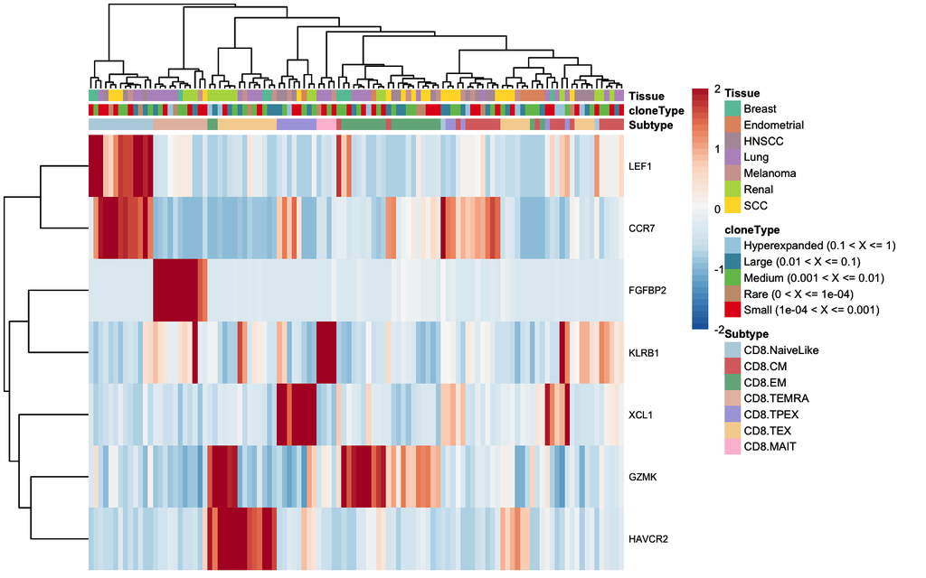

```r
celltype.heatmap(ref, genes = c("LEF1", "CCR7", "GZMK", "FGFBP2", "XCL1", "HAVCR2",
    "KLRB1"), ref = ref, metadata = c("cloneType", "Tissue"), order.by = "Tissue",
    cluster_genes = T, cluster_samples = T)
```

## Customize palette

Finally, we can also change the metadata palette if we input a list of palette in the correct format in `palette` parameter. If needed, the clusters colors can be changed using the name `Subtype` from the list of palettes.

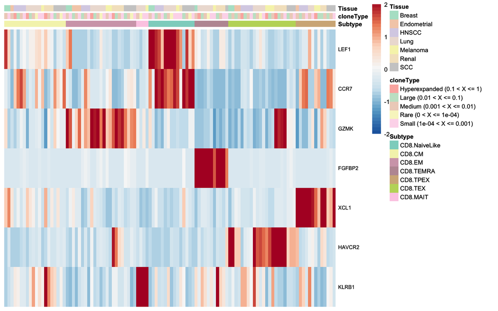

```r
my.palettes <- list()

# Setup Subtype colors with functional.cluster metadata
my.palettes[["Subtype"]] <- colorRampPalette(brewer.pal(n = 8, name = "Set3"))(length(levels(ref$functional.cluster)))
names(my.palettes[["Subtype"]]) <- levels(ref$functional.cluster)

# Setup cloneType metadata colors
ref$cloneType <- factor(ref$cloneType)
my.palettes[["cloneType"]] <- colorRampPalette(brewer.pal(n = 8, name = "Pastel1"))(length(levels(ref$cloneType)))
names(my.palettes[["cloneType"]]) <- levels(ref$cloneType)

# Setup Tissue metadata colors
ref$Tissue <- factor(ref$Tissue)
my.palettes[["Tissue"]] <- colorRampPalette(brewer.pal(n = 8, name = "Pastel2"))(length(levels(ref$Tissue)))
names(my.palettes[["Tissue"]]) <- levels(ref$Tissue)

celltype.heatmap(ref, genes = c("LEF1", "CCR7", "GZMK", "FGFBP2", "XCL1", "HAVCR2",
    "KLRB1"), metadata = c("cloneType", "Tissue"), order.by = "Tissue", palette = my.palettes)
```

# Heatmap example

You can now plot the averaged gene expression profiles on the heatmap, and display multiple metadata on one single plot.

## Compute DEGs

```r
DefaultAssay(ref) <- "RNA"
ref <- NormalizeData(ref)
degs <- FindAllMarkers(ref, only.pos = T)
degs <- degs |>
    arrange(cluster, -avg_log2FC) |>
    group_by(cluster) |>
    top_n(1, avg_log2FC)
```

## Plot heatmap

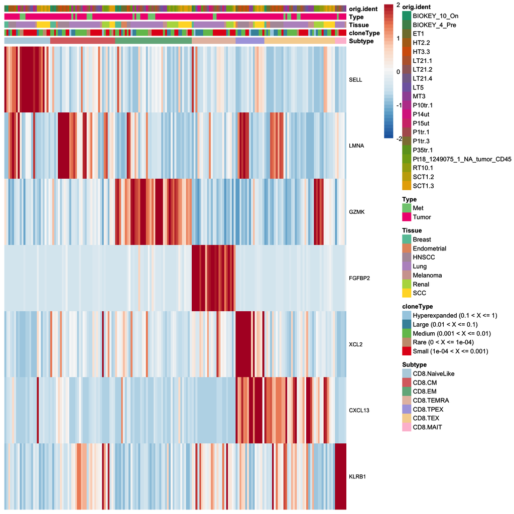

```r
celltype.heatmap(ref, genes = degs$gene, ref = ref, metadata = c("cloneType", "Tissue",
    "Type", "orig.ident"), order.by = "Tissue")
```